# GDP per capita and Gini index, all countries

## Introduction

- This page plots the Gini index of income inequality against GDP per capita for every country and survey year in the World Bank data: 2,421 country-years, 171 countries, 1963-2025.
- Outputs: all countries in one panel, coloured by group (Figure 1); one panel per group, other countries in grey (Figure 2).
- Groups: the World Bank regions re-cut into 14 groups (city states, oil producers, Sub-Saharan Africa by former colonial power, …); rules below.
- Data are read from the saved WDI API responses in `data/`; the download-and-build chunk is a record and is not run (`eval: false`).

Data sources:

- World Bank, World Development Indicators (WDI), via the [WDI API](https://api.worldbank.org/v2/)
  - `NY.GDP.PCAP.KD`: GDP per capita, constant 2015 US$ (market exchange rates; from 1960)
  - `SI.POV.GINI`: Gini index (0-100), World Bank Poverty and Inequality Platform estimates from household surveys
  - `NY.GDP.PETR.RT.ZS`: oil rents, % of GDP (to flag oil producers)
  - Country metadata (`/v2/country`): World Bank region; aggregates (World, income groups, regions) dropped

How the data are constructed:

- Raw API responses saved once to `data/*.json`; later renders read the local copies
- Country-years kept only where the Gini index is available (and GDP per capita is non-missing)
- Constant-US$ GDP per capita (not PPP) is used to keep Gini surveys before 1990, when PPP series start
- Market exchange rates understate incomes in low-price countries relative to PPP
- Gini is income-based for some countries and consumption-based for others, so levels are not strictly comparable across countries
- Groups: World Bank regions, re-cut as follows (applied in this order)
  - City states: SGP, HKG, MAC, LUX, MLT, MCO, SMR, LIE, AND
  - Oil producers: mean oil rents >= 10% of GDP over all available years
  - East Asia & Pacific split into Pacific (Oceania: AUS, NZL, Pacific islands) and East & Southeast Asia
  - Europe & Central Asia split into Central Asia & Caucasus (5 Central Asian states, ARM, AZE, GEO), Eastern Europe (former socialist Europe, Russia, Ukraine, Belarus, Moldova, plus TUR) and Western Europe (the rest)
  - Sub-Saharan Africa split by former colonial power: Francophone (France, Belgium; CMR counted here), Anglophone (Britain; SDN, SSD, SYC counted here; also LBR, English-speaking, never colonised), Other (Portugal, Spain, Italy, never colonised: e.g. MOZ, GNB, CPV, STP, ETH)
- Dots of the same country are joined in year order; the larger dot is its latest survey year

```r
options(repos = c(CRAN = "https://cran.ism.ac.jp/"))  # Japan mirror (ISM, Tokyo)
pkgs <- c("data.table", "jsonlite", "qs2", "ggplot2", "ggrepel")
new <- pkgs[!vapply(pkgs, requireNamespace, logical(1), quietly = TRUE)]
if (length(new) > 0) install.packages(new)
library(data.table)
library(ggplot2)
dir.create("data", showWarnings = FALSE)
```

```r
# Not run at render (kept as a record): builds data/gdp_gini.qs2, read in the next chunk
api <-"https://api.worldbank.org/v2/"
src <- c(gini.json = "country/all/indicator/SI.POV.GINI?format=json&per_page=30000",
         gdppc_usd.json = "country/all/indicator/NY.GDP.PCAP.KD?format=json&per_page=30000",
         oil.json = "country/all/indicator/NY.GDP.PETR.RT.ZS?format=json&per_page=30000",
         country.json = "country?format=json&per_page=400")
for (f in names(src)) if (!file.exists(file.path("data", f)))
  download.file(paste0(api, src[f]), file.path("data", f), mode = "wb")

wdi <-function(f, v) {
  x <- as.data.table(jsonlite::fromJSON(file.path("data", f), flatten = TRUE)[[2]])
  x[, .(iso3 = countryiso3code, year = as.integer(date), value)][, setnames(.SD, "value", v)]
}
gini <- wdi("gini.json", "gini")[!is.na(gini)]
gdp  <- wdi("gdppc_usd.json", "gdppc")[!is.na(gdppc)]
ctry <- as.data.table(jsonlite::fromJSON("data/country.json", flatten = TRUE)[[2]])
ctry <- ctry[region.value != "Aggregates", .(iso3 = id, country = name, region = trimws(region.value))]

gg <- merge(gini, gdp, by = c("iso3", "year"))          # keeps Gini years only
gg <- merge(gg, ctry, by = "iso3")                      # drops aggregates

# Regrouping (World Bank regions split; city states and oil producers pulled out of all groups)
oil  <- wdi("oil.json", "oil")[!is.na(oil)]
oilp <- oil[, .(oil = mean(oil)), by = iso3][oil >= 10, iso3]      # mean oil rents >= 10% of GDP
city <- c("SGP", "HKG", "MAC", "LUX", "MLT", "MCO", "SMR", "LIE", "AND")
pac  <- c("AUS", "NZL", "PNG", "FJI", "SLB", "VUT", "WSM", "TON", "KIR", "TUV", "NRU", "FSM", "MHL", "PLW")
cas  <- c("KAZ", "KGZ", "TJK", "TKM", "UZB", "ARM", "AZE", "GEO")
eeu  <- c("ALB", "BGR", "BIH", "BLR", "CZE", "EST", "HRV", "HUN", "LTU", "LVA", "MDA", "MKD",
          "MNE", "POL", "ROU", "RUS", "SRB", "SVK", "SVN", "UKR", "XKX", "TUR")
# SSA by former colonial power: French or Belgian = francophone, British = anglophone
fra  <- c("BEN", "BFA", "BDI", "CAF", "TCD", "COM", "COG", "COD", "CIV", "GAB", "GIN", "MDG",
          "MLI", "MRT", "NER", "RWA", "SEN", "TGO", "CMR")
eng  <- c("BWA", "GMB", "GHA", "KEN", "LSO", "LBR", "MWI", "MUS", "NAM", "NGA", "SLE", "ZAF",
          "SSD", "SDN", "SWZ", "TZA", "UGA", "ZMB", "ZWE", "SYC")
gg[, wb_region := region]
gg[, region := fcase(iso3 %in% city, "City states", iso3 %in% oilp, "Oil producers",
                     iso3 %in% pac, "Pacific", wb_region == "East Asia & Pacific", "East & Southeast Asia",
                     iso3 %in% cas, "Central Asia & Caucasus", iso3 %in% eeu, "Eastern Europe",
                     wb_region == "Europe & Central Asia", "Western Europe",
                     iso3 %in% fra, "Francophone SSA", iso3 %in% eng, "Anglophone SSA",
                     wb_region == "Sub-Saharan Africa", "Other SSA",
                     wb_region == "Middle East, North Africa, Afghanistan & Pakistan", "MENA, Afghanistan & Pakistan",
                     default = wb_region)]
setorder(gg, iso3, year)
gg[, latest := year == max(year), by = iso3]
qs2::qs_save(gg, "data/gdp_gini.qs2")
fwrite(gg, "data/gdp_gini.csv")
```

```r
gg <- qs2::qs_read("data/gdp_gini.qs2")                 # made by the data chunk above
gg[, .(countries = uniqueN(iso3), obs = .N, from = min(year), to = max(year)), by = region]
```

```
                          region countries   obs  from    to
                          <char>     <int> <int> <int> <int>
 1:                Oil producers        18    98  1981  2023
 2:               Eastern Europe        22   504  1987  2024
 3:    Latin America & Caribbean        25   489  1979  2025
 4:      Central Asia & Caucasus         5   100  1996  2025
 5:                      Pacific        12    38  1981  2023
 6:               Western Europe        18   504  1968  2023
 7:              Francophone SSA        17   103  1980  2024
 8:                   South Asia         6    42  1977  2023
 9:               Anglophone SSA        18    93  1985  2023
10:                North America         2   108  1963  2024
11:        East & Southeast Asia        11   171  1981  2025
12:                    Other SSA         5    24  1991  2022
13: MENA, Afghanistan & Pakistan        10    90  1979  2024
14:                  City states         2    57  1985  2023
```

```r
gg[region %in% c("City states", "Oil producers", "Francophone SSA", "Anglophone SSA", "Other SSA"), .(members = paste(unique(iso3), collapse = " ")), by = region]
```

```
            region
            <char>
1:   Oil producers
2: Francophone SSA
3:  Anglophone SSA
4:       Other SSA
5:     City states
                                                                   members
                                                                    <char>
1: AGO ARE AZE COG DZA GAB GNQ IRN IRQ KAZ NGA QAT SSD TKM TLS TTO VEN YEM
2:     BDI BEN BFA CAF CIV CMR COD COM GIN MDG MLI MRT NER RWA SEN TCD TGO
3: BWA GHA GMB KEN LBR LSO MUS MWI NAM SDN SLE SWZ SYC TZA UGA ZAF ZMB ZWE
4:                                                     CPV ETH GNB MOZ STP
5:                                                                 LUX MLT
```

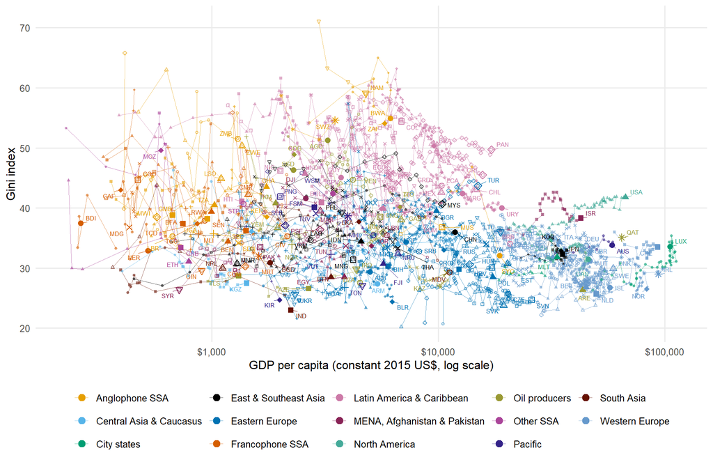

Figure 1: GDP per capita (constant 2015 US$, log scale) and Gini index; each line joins one country’s survey years; colour = group, shape = country within group (12 shapes, recycled); ISO3 code at the latest survey year.

```r
# Okabe-Ito + Paul Tol colours (colour-blind aware), one per group
cols <- c("#E69F00", "#56B4E9", "#009E73", "#000000", "#0072B2", "#D55E00", "#CC79A7",
          "#882255", "#44AA99", "#999933", "#AA4499", "#332288", "#661100", "#6699CC")
names(cols) <- sort(unique(gg$region))
# Point shapes (solid, then hollow), cycled by country order within group
shp <- c(16, 17, 15, 18, 1, 2, 0, 5, 6, 4, 3, 8)
gg[, sid := factor((match(iso3, unique(iso3)) - 1) %% length(shp) + 1), by = region]
p_all <- ggplot(gg, aes(gdppc, gini, colour = region, shape = sid, group = iso3)) +
  geom_path(linewidth = 0.3, alpha = 0.6) +
  geom_point(size = 1, alpha = 0.6) +
  geom_point(data = gg[latest == TRUE], size = 2.2) +
  ggrepel::geom_text_repel(data = gg[latest == TRUE], aes(label = iso3), size = 2.3, show.legend = FALSE,
                           max.overlaps = Inf, min.segment.length = 0, segment.size = 0.2, seed = 1) +
  scale_x_log10(labels = scales::label_dollar(accuracy = 1)) +
  scale_colour_manual(values = cols, name = NULL) +
  scale_shape_manual(values = shp, guide = "none") +
  labs(x = "GDP per capita (constant 2015 US$, log scale)", y = "Gini index") +
  theme_minimal(base_size = 12) +
  theme(legend.position = "bottom", panel.grid.minor = element_blank()) +
  guides(colour = guide_legend(nrow = 3, override.aes = list(size = 3)))
ggsave("data/gdp_gini_all.png", p_all, width = 10, height = 6.5, dpi = 200, bg = "white")
p_all
```

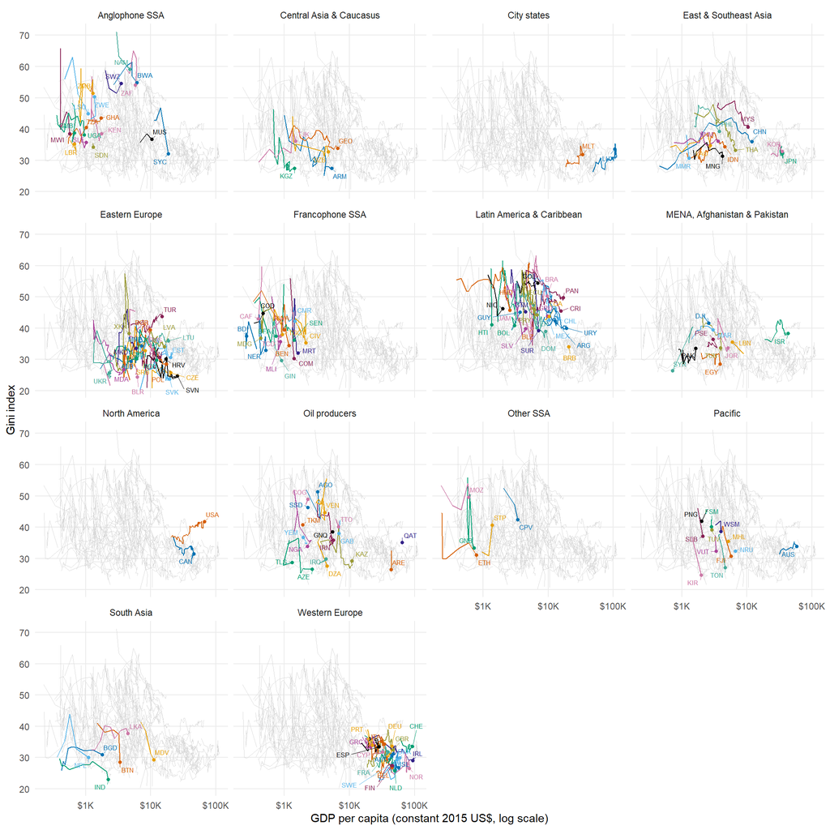

Figure 2: Same data by region: one colour per country (12 colours, recycled within a region), labelled with its ISO3 code at the latest survey year; grey = all other countries.

```r
bg <- gg[, .(gdppc, gini, iso3)]                        # background without region column
# Country colours: Paul Tol + Okabe-Ito (colour-blind-aware), cycled by country order within region
ccol <- c("#0072B2", "#D55E00", "#009E73", "#CC79A7", "#E69F00", "#56B4E9", "#000000",
          "#882255", "#44AA99", "#999933", "#AA4499", "#332288")
gg[, cid := factor((match(iso3, unique(iso3)) - 1) %% length(ccol) + 1), by = region]
p_reg <- ggplot(gg, aes(gdppc, gini, group = iso3)) +
  geom_path(data = bg, colour = "grey85", linewidth = 0.2) +
  geom_path(aes(colour = cid), linewidth = 0.4) +
  geom_point(data = gg[latest == TRUE], aes(colour = cid), size = 1.2) +
  ggrepel::geom_text_repel(data = gg[latest == TRUE], aes(label = iso3, colour = cid), size = 2.3,
                           max.overlaps = Inf, min.segment.length = 0, segment.size = 0.2, seed = 1) +
  facet_wrap(~region, ncol = 4) +
  scale_x_log10(labels = scales::label_dollar(accuracy = 1, scale_cut = scales::cut_short_scale())) +
  scale_colour_manual(values = ccol, guide = "none") +
  labs(x = "GDP per capita (constant 2015 US$, log scale)", y = "Gini index") +
  theme_minimal(base_size = 11) +
  theme(panel.grid.minor = element_blank())
ggsave("data/gdp_gini_region.png", p_reg, width = 11, height = 11, dpi = 200, bg = "white")
p_reg
```

Saved in `data/`:

- `gini.json`, `gdppc_usd.json`, `oil.json`, `country.json`: raw WDI API responses
- `gdp_gini.qs2`, `gdp_gini.csv`: merged country-year panel
- `gdp_gini_all.png`, `gdp_gini_region.png`: the two figures